[figure not shown]

[figure not shown]

# AANHPI Student Survey

## Spring 2025

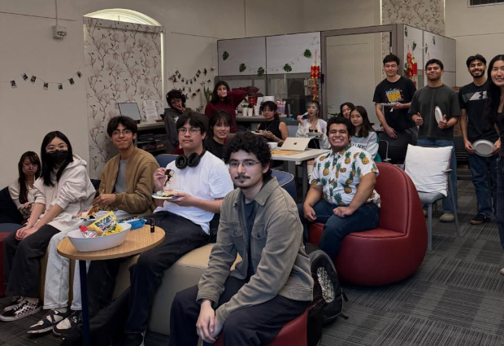

# About the Survey

The purpose of the survey was to examine the experiences of Asian American, Native Hawaiian, and Pacific Islander (AANHPI) students at Fullerton College to see how the AANHPI Student Achievement Program Grant can offer more resources, programs and services to its AANHPI students.

A total of 213 AANHPI students responded to the survey during spring 2025 (May 7 – May 22, 2025). The survey was primarily distributed through email to students who identified as Asian and/or Pacific Islander, as well as in class.

Overall, AANHPI students report strong levels of confidence and belonging at the college. Most students expressed readiness to handle coursework and confidence in their academic decisions, and students highlighted feeling welcomed, respected, and supported by faculty and staff. These findings indicate that the campus environment is broadly inclusive and academically supportive, reinforcing students’ ability to succeed.

At the same time, there are several areas for growth. Although students feel cared for by faculty and staff, peer-to-peer connections were comparatively weaker, suggesting that additional efforts to strengthen student networks may be valuable. Leadership development also emerged as an area to expand. Specifically, although students perceive leadership opportunities as accessible, many lack confidence in stepping into these roles. Finally, financial challenges were ranked lowest, with students continuing to report significant stress related to affordability and basic needs.

The AANHPI Student Survey asked students about their experiences across 14 key areas. Each area represents a theme that influences how students feel, learn, and succeed in college. For example, College Confidence captures how capable students feel in handling coursework, while Financial Challenges and Needs investigates the stress students experience around affordability and resources.

# Summary

**College confidence, belonging, community, and mattering** were among the strongest areas indicated by students, suggesting that most students felt academically capable, welcomed, supported by faculty and staff, and valued at the institution.

**Family support** was largely positive, particularly around encouragement to pursue education, though experiences varied with respect to academic pressure and emotional support.

**Visibility** of AANHPI students on campus was moderate, with many students reporting some representation in campus spaces and curriculum, though experiences were not consistent across all respondents.

**Leadership development** was rated moderately, with most students perceiving leadership opportunities as open, but fewer feeling personally confident stepping into leadership roles.

**Campus racial climate** was viewed as generally inclusive and fair; however, a substantial share of students reported experiencing or witnessing racial discrimination or bias targeting AANHPI students on campus, signaling an important area for attention.

**Campus engagement** was higher in the classroom than in campus activities or student organizations.

**Mental health wellbeing** showed moderate agreement, indicating that many students reported access to supportive resources and felt comfortable seeking help, though these supports were not uniformly experienced across all respondents.

**Cultural identity development and empowerment** also reflected moderate agreement, suggesting that while some students felt encouraged to express and affirm their AANHPI identity, there remains opportunity to further strengthen identity-affirming spaces and peer connections.

**Support services** were rated moderately, particularly with respect to awareness of AANHPI-specific resources and the availability of culturally responsive academic counseling and services.

**Financial challenges and needs** represented one of the weaker areas, as many students reported ongoing financial stress and concerns about stability, alongside lower perceptions of the accessibility and promotion of AANHPI-specific scholarships and grants.

**Figure 1:** Overview of Survey Constructs

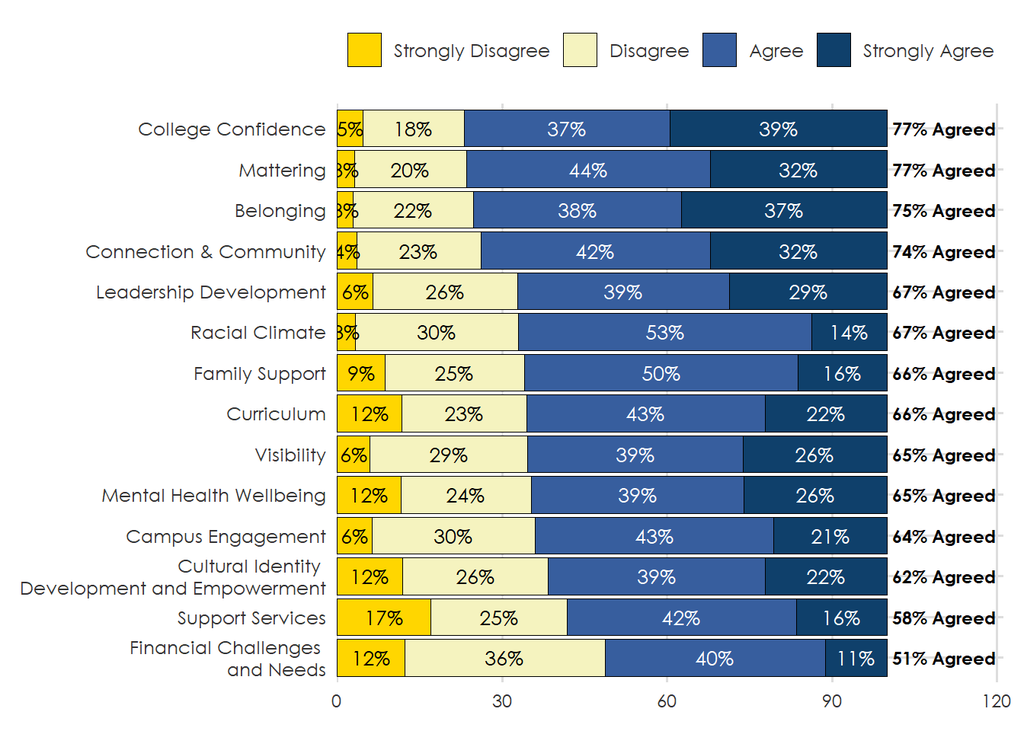

Figure 1

# Data Exploration

## College Confidence

Students generally report high confidence in their ability to handle college work and reach their academic expectations. Over 80% report being ready for their classes and believe they can overcome challenges, while nearly 79% say their experiences at the institution have strengthened their confidence in making academic decisions. This shows that the campus effectively supports students’ self-efficacy and readiness.

**Figure 2:** College Confidence

[interactive chart not shown]

Figure 2

## Belonging

Most students feel that they belong on campus. Overall, 76% say they personally feel like they belong, and even more students agree that they are welcomed by peers (81%) and feel that their cultural background is respected (85%). Since feelings of a respected and valued cultural background is stronger than feelings of belonging, these findings suggest that belonging for AANAPI students may have to do with other factors in addition to cultural background.

**Figure 3:** Belonging

[interactive chart not shown]

Figure 3

## Connection & Community

Students largely viewed the campus community as supportive of AANHPI students. Faculty and staff are seen as very supportive, with nearly 86% of students agreeing that they help AANHPI students succeed. Pride in the AANHPI student community is also high (81%). However, **fewer students indicated having meaningful relationships with peers who share their cultural background** (65%), suggesting that students may need additional opportunities to further strengthen those peer connections.

**Figure 4:** Connection and Community

[interactive chart not shown]

Figure 4

## Mattering

Students generally feel that they matter on campus. Around 80–83% report that faculty, staff, and the institution care about their well-being and listen to their needs, and 78% feel personally valued. This emphasizes the importance of faculty and staff engagement in supporting students’ sense of mattering.

**Figure 5:** Mattering

[interactive chart not shown]

Figure 5

## Family Support

Family support plays a critical role. Between 70–86% of students report that their families encourage them, provide emotional support, and understand financial challenges. About 60% also experience academic pressure from family, highlighting a balance of encouragement and expectation in students’ home lives.

**Figure 6:** Family Support

[interactive chart not shown]

Figure 6

## Visibility

Students perceive moderate visibility of AANHPI representation on campus. Between 69–77% agreed that their cultural background is reflected in campus events, leadership, and curriculum. This suggests continued opportunities to enhance cultural representation across programs and learning experiences. Additionally, there was **less agreement on students’ *specific* cultural backgrounds being reflected on campus, in the curriculum, or in campus programming.**

**Figure 7:** Visibility

[interactive chart not shown]

Figure 7

## Leadership Development

Leadership opportunities are largely seen as open, with 81% agreement. However, confidence in stepping into leadership roles is lower (66%), indicating a need for mentoring or programs that build students’ leadership readiness. This gap suggests that while structural access to leadership may be present, **additional support may be needed to build leadership confidence and participation.**

**Figure 8:** Leadership Development

[interactive chart not shown]

Figure 8

## Campus Racial Climate

Most students feel that AANHPI students are treated fairly (84%) and that the campus is inclusive (79%). However, **41% reported witnessing or experiencing incidents of racial bias, highlighting that anti-discrimination or anti-racist support may be needed despite generally favorable perceptions of campus climate.**

**Figure 9:** Campus Racial Climate

[interactive chart not shown]

Figure 9

## Campus Engagement

Engagement patterns differed by context. Students are confident participating in class discussions (77–86%). In contrast, **regular participation in campus activities, clubs, or organizations was substantially lower (47%),** with fewer than half of the students engaging in campus activities, clubs, or student organizations.

**Figure 10:** Campus Engagement

[interactive chart not shown]

Figure 10

## Mental Health Wellbeing

Responses indicated moderate support for mental health wellbeing. Campus mental health support is perceived positively, with 71–73% of students reporting supportive services and culturally sensitive care. However, about 10% of students do not have a supportive community on campus that helps them feel less alone and isolated.

**Figure 11:** Mental Health Wellbeing

[interactive chart not shown]

Figure 11

## Cultural Identity Development and Empowerment

Students reported moderate levels of cultural empowerment, with 62–73% agreeing that campus experiences strengthen identity and encourage cultural expression. Some students felt that their experiences strengthened pride in their AANHPI identity and encouraged cultural expression, but agreement was not universal. Opportunities remain to further support identity affirmation and connections with peers who share and validate cultural identities.

**Figure 12:** Cultural Identity Development and Empowerment

[interactive chart not shown]

Figure 12

## Curriculum

Students moderately agree that courses provide opportunities to learn about AANHPI history, culture, and perspectives (62–72%). Fewer students consistently encountered AANHPI-related content in their classes, indicating an opportunity to strengthen curricular representation across programs and disciplines.

**Figure 13:** Curriculum

[interactive chart not shown]

Figure 13

## Support Services

Perceptions of support services were mixed. Experiences with AANHPI-focused support services are mixed. While mental health services were rated positively (79%), knowledge of resources and personalized academic counseling were lower (62–73%). While some students felt that AANHPI-specific services exist and that mental health services are culturally sensitive, fewer students reported awareness of available resources or receiving personalized, culturally responsive academic counseling. This suggests a need for improved visibility, access, and alignment of services with AANHPI student needs.

**Figure 14:** Support Services

[interactive chart not shown]

Figure 14

## Financial Challenges and Needs

Financial wellbeing emerged as a key area of concern. Students report 58–71% agreement that scholarships, grants, and basic needs resources are accessible. Many students reported stress related to managing educational and personal expenses and ongoing worries about financial stability. Perceptions of the accessibility and promotion of AANHPI-specific scholarships and grants were relatively low, although comfort accessing basic needs services was somewhat higher.

**Figure 15:** Financial Challenges and Needs of AANHPI Students

[interactive chart not shown]

Figure 15